# Market Data Understanding

# Beta ($\beta$ ) of a Stock

This is the regression slope co-efficient when the return of the asset is regressed on the return on the market

**$\beta = 1.0$:** The stock moves exactly in sync with the market.

**$\beta > 1.0$:** The stock is "High Beta" it amplifies market moves. (If the market goes up 1%, the stock might go up 1.5%). These are aggressive growth stocks.

**$\beta < 1.0$:** The stock is "Low Beta" it is less volatile than the market. These are often defensive, steady-dividend stocks.

**The Formula** $$\beta = \frac{\text{Cov}(R_s, R_m)}{\text{Var}(R_m)}$$

Where:

$R_s$: The log returns of your specific stock (e.g., KCB).

$R_m$: The log returns of the benchmark (e.g., NSE 20 Index).

$\text{Cov}(R_s, R_m)$: How the stock and the market move together.

$\text{Var}(R_m)$: The volatility of the market itself.

| ticker | 0 |
| --- | --- |
| ABSA | 1.153461 |
| COOP | 0.949976 |
| DTK | 0.972024 |
| EQTY | 1.022494 |
| IMH | 1.019259 |
| KCB | 1.394468 |
| NCBA | 0.952064 |
| SBIC | 0.761263 |
| SCBK | 0.834212 |

**dtype:** float64

| Ticker | Beta | Market Risk Category |
| --- | --- | --- |
| KCB | 1.39 | Aggressive / High Sensitivity |
| EQTY | 1.02 | Market-Mirror |
| IMH | 1.02 | Market-Mirror |
| DTK | 0.97 | Defensive / Neutral |
| NCBA | 0.95 | Defensive / Neutral |
| COOP | 0.95 | Defensive / Neutral |
| ABSA | 1.15 | Aggressive |
| SCBK | 0.83 | Defensive |
| SBIC | 0.76 | Defensive / Low Sensitivity |

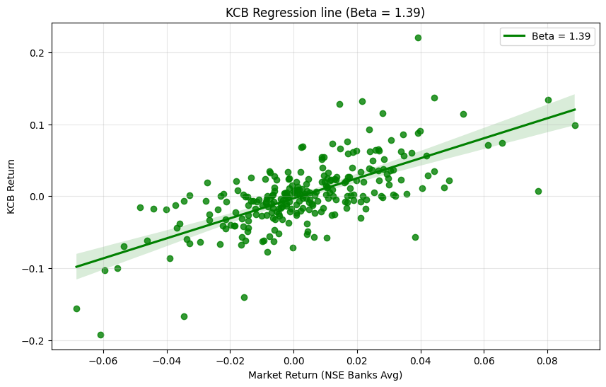

# Moving Average Convergence Divergence (MACD)

The Moving Average Convergence Divergence (MACD) is a trend-following momentum indicator that shows the mathematical relationship between two different Exponential Moving Averages (EMAs) of an asset's price.

## The MACD Formula

The complete MACD indicator relies on three specific calculations that form the lines you see on a chart:

1. **The MACD Line:** This is the primary line that measures the distance between short-term and long-term momentum.

$$ \text{MACD}_t = \text{EMA}_{12,t} - \text{EMA}_{26,t} $$

2. **The Signal Line:** This is a smoothed version of the MACD line used to trigger buy and sell signals.

$$ \text{Signal}_t = \text{EMA}_{9}\left(\text{EMA}_{12,t}-\text{EMA}_{26,t}\right) $$

3. **The MACD Histogram:** This is the bar chart that visually displays the exact gap between the MACD Line and the Signal Line.

$$ \text{Histogram}_t = \text{MACD}_t - \text{Signal}_t $$

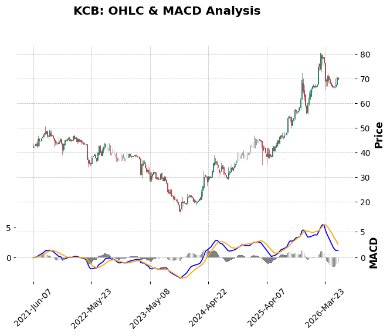

# Investment Insights

[output not shown]

## NB:When the MACD line crosses below the Signal line, it is mathematically flagging that the short-term momentum has fallen behind the longer-term trend, which is the classic signal for a coming bearish move.

# Volume Weighted Average Price

$$\text{VWAP}=\frac{\sum (\text{TypicalPrice}\times \text{Volume})}{\sum \text{Volume}}$$

**Typical Price (TP):** The average of the High (H), Low (L), and Close (C) prices for a specific period

$\text{Typical Price}=\frac{H+L+C}{3}$

Volume: The number of shares, contracts, or tokens traded during that specific period.

|  | ticker | time | open | high | low | close | Volume | log_return | static_volatility | rolling_vol | rsi_4 | macd_line | signal_line | macd_hist |
| --- | --- | --- | --- | --- | --- | --- | --- | --- | --- | --- | --- | --- | --- | --- |
| 0 | ABSA | 2020-09-14 | 9.80 | 10.0 | 9.80 | 9.84 | 825100 | 0.014127 | 0.039545 | 0.025455 | 48.076923 | 0.000000 | 0.000000 | 0.000000 |
| 1 | ABSA | 2020-09-21 | 9.80 | 10.0 | 9.60 | 9.98 | 4024700 | 0.014127 | 0.039545 | 0.025455 | 48.076923 | 0.011168 | 0.002234 | 0.008934 |
| 2 | ABSA | 2020-09-28 | 10.20 | 10.8 | 9.66 | 9.80 | 4160000 | -0.018201 | 0.039545 | 0.025455 | 48.076923 | 0.005432 | 0.002873 | 0.002559 |
| 3 | ABSA | 2020-10-05 | 9.82 | 9.9 | 9.36 | 9.44 | 2574100 | -0.037426 | 0.039545 | 0.025455 | 48.076923 | -0.027842 | -0.003270 | -0.024572 |
| 4 | ABSA | 2020-10-12 | 9.40 | 9.8 | 9.30 | 9.80 | 316300 | 0.037426 | 0.039545 | 0.033308 | 48.076923 | -0.024877 | -0.007591 | -0.017285 |

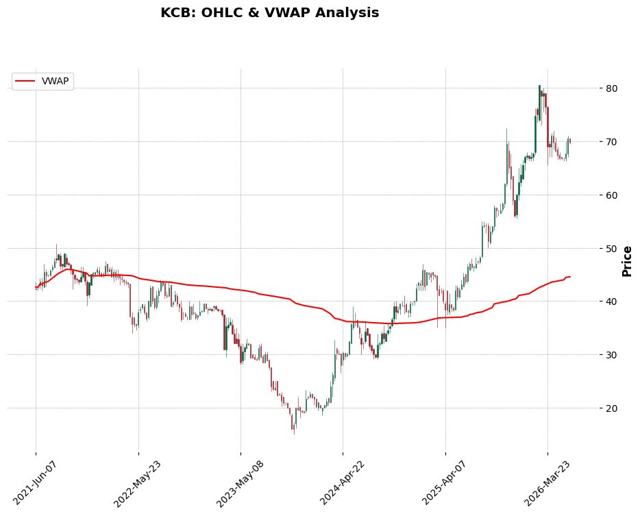

# NCBA

[figure not shown]

# NCBA Close Price

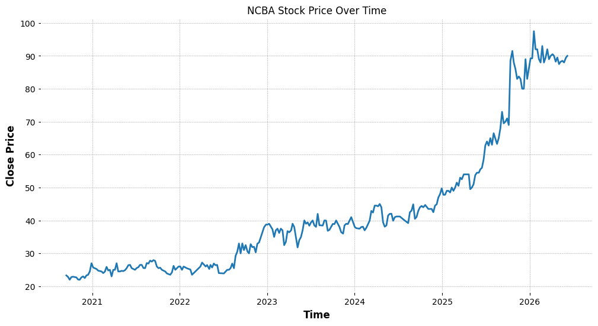

# NCBA Static Volatility Compared to the Aggregate Banking Market

[figure not shown]

# NCBA Dynamic Volatility Compared to the Aggregate Banking Market

[figure not shown]

```
97.5
```

```
22.0
```

# NCBA All-Time High = 97.5

# NCBA All-Time Low = 22.0

# Relative Strength Index(RSI) Of NCBA

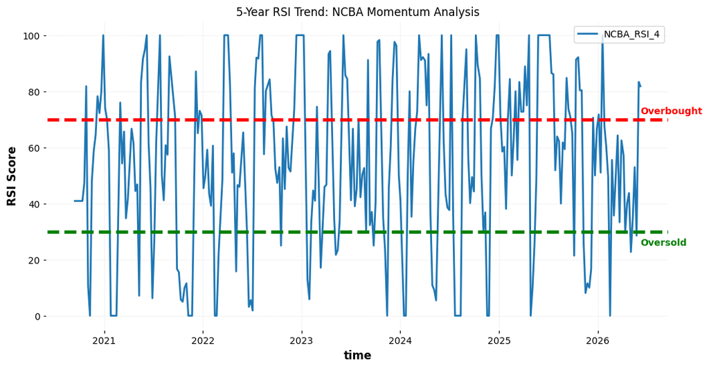

```
matplotlib.pyplot.show
def show(*args, **kwargs) -> None
```

[output not shown]

# Beta ($\beta$ ) of the NCBA Stock

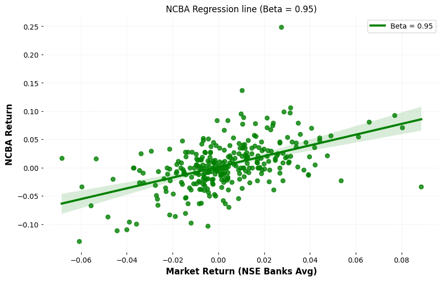

# Moving Average Convergence Divergence (NCBA)

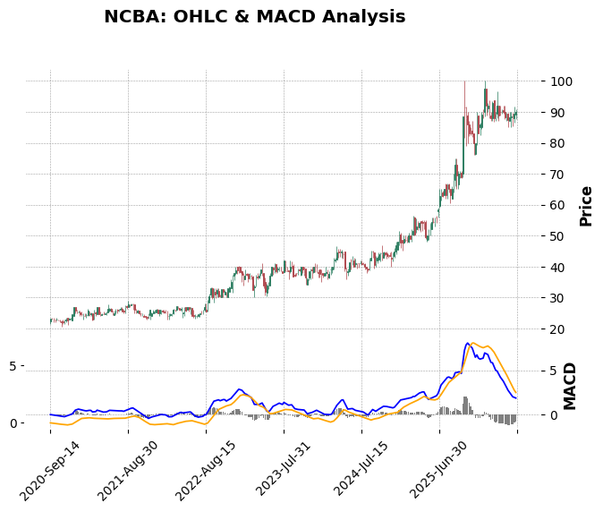

# Volume Weighted Average Price (NCBA)

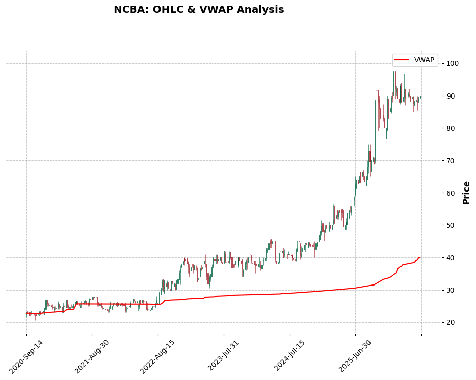

# Equity Bank

[figure not shown]

# Equity Bank Close Price Trend

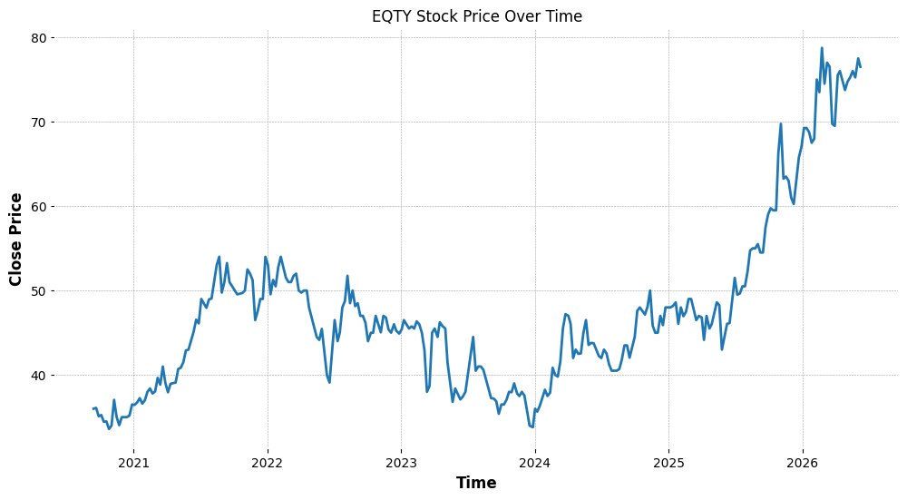

# Equity Bank Static Volatility

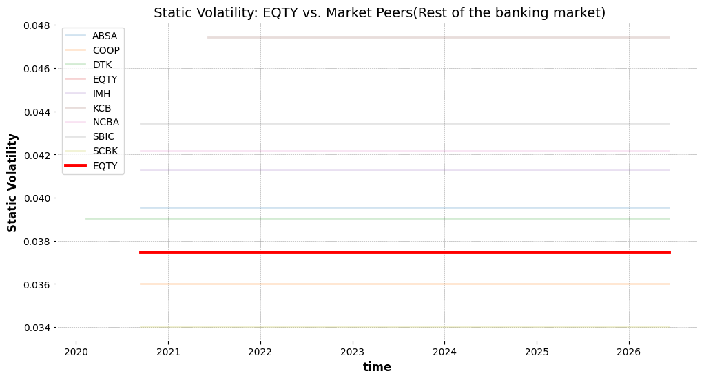

# Equity Bank Dynamic Volatility

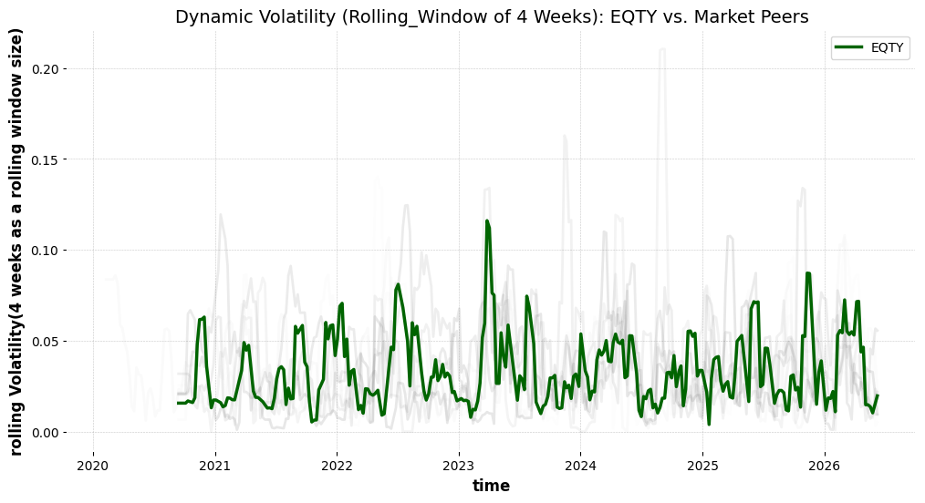

```
78.75
```

```
33.599998
```

# EQTY_Bank All Time High = 78.75

# EQTY_bANK All Time Low = 33.59

# Relative Strength Index(RSI) Of EQTY

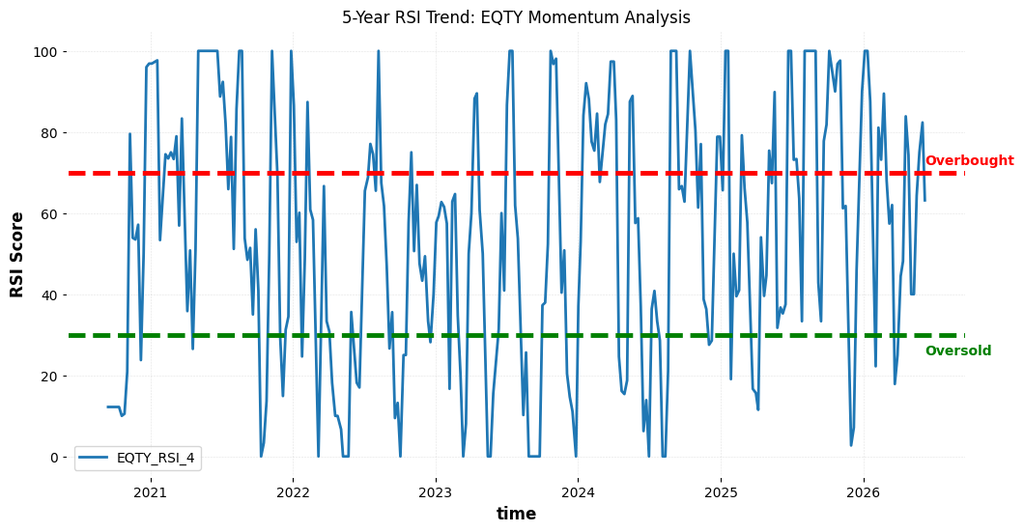

```
matplotlib.pyplot.show
def show(*args, **kwargs) -> None
```

[output not shown]

# Beta ($\beta$ ) of the EQTY Stock

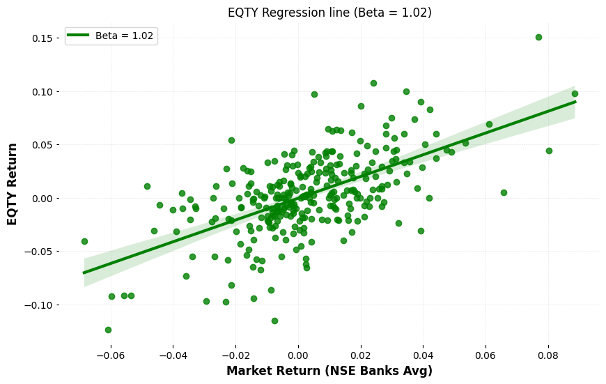

# Moving Average Convergence Divergence (EQTY)

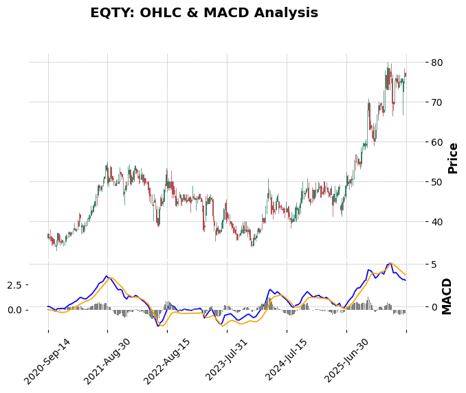

# Volume Weighted Average Price Of EQTY Stock

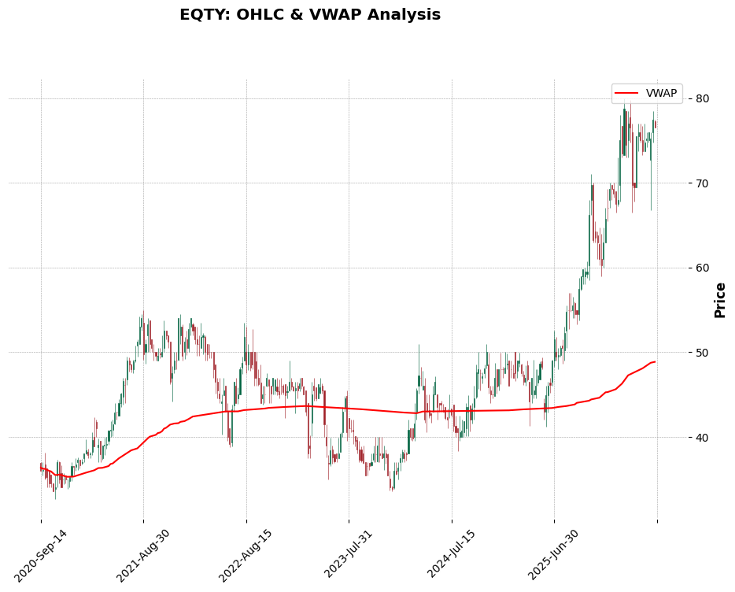

# I & M Bank

[figure not shown]

# I&M Close Price

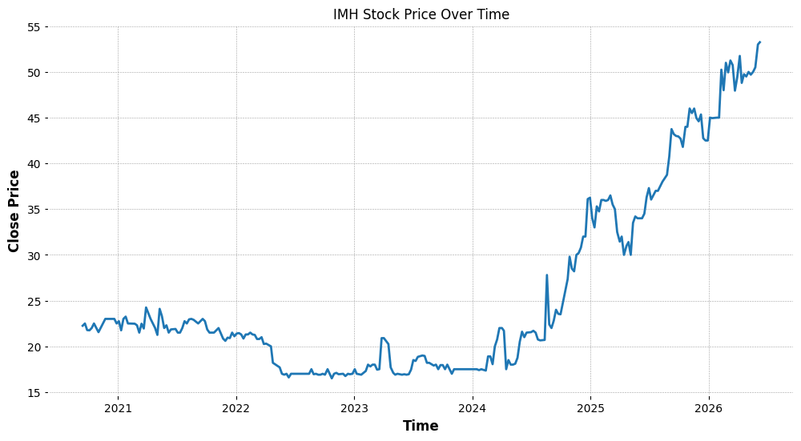

# I&M Bank Static Volatility

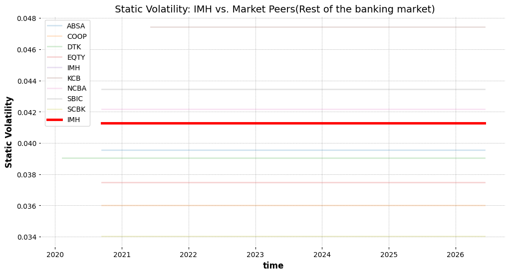

# I&M Bank Dynamic Volatility

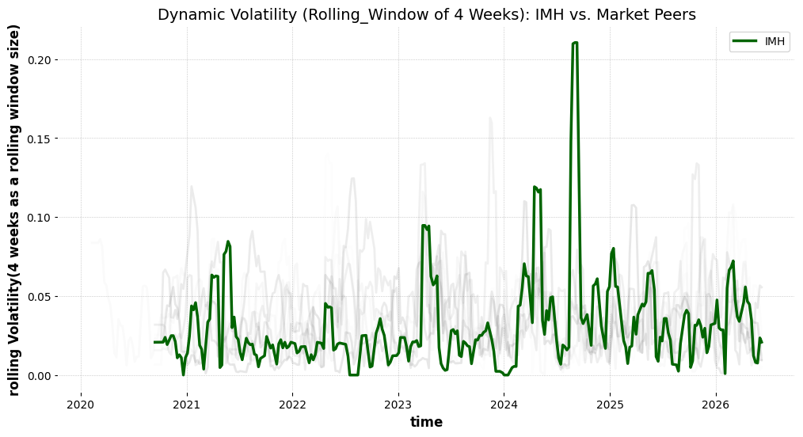

# Relative Strength Index Of IMH

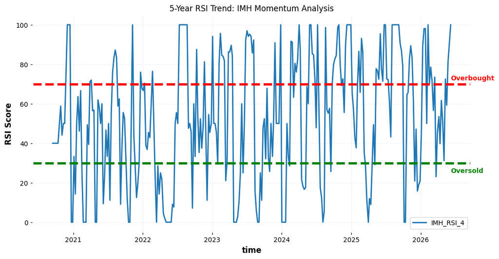

```
matplotlib.pyplot.show
def show(*args, **kwargs) -> None
```

[output not shown]

# Beta ( $\beta$ ) of the IMH Stock

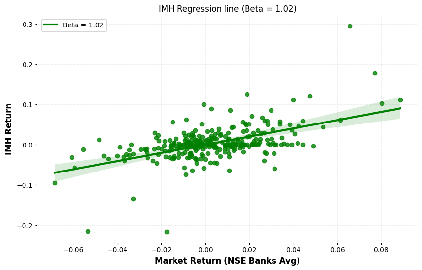